# Simulation Study **Vol. 2**

Proof that my codes runs without errors:

## Systems with Different Queque Capacity I

Implemented the script as was asked of me. To simplyfy the code I decided to write a short class that saves all the measurements in a single object. The plot and printout result in: (orange in the middle!)

```python
from part2_simstudy import *
from matplotlib import pyplot as pp
```

```
-----------------------------------------------
Gonna do a sim with paras - S:5
Name: Queue length, Mean: 2.5789770499999993, Variance: 0.29535165316736484
Name: Waiting time, Mean: 1239.4965159774097, Variance: 96637.23719089417
-----------------------------------------------
Gonna do a sim with paras - S:6
Name: Queue length, Mean: 3.04024339, Variance: 0.5979151742384464
Name: Waiting time, Mean: 1466.672018068835, Variance: 187659.34984497286
-----------------------------------------------
Gonna do a sim with paras - S:7
Name: Queue length, Mean: 3.4949308300000004, Variance: 0.880525102354766
Name: Waiting time, Mean: 1687.7388299477032, Variance: 266162.43045564694
```

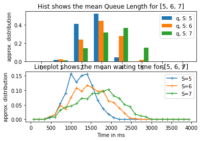

```python
task_2_7_1()
```

## Systems with Different Queque Capacity II

The same code is executed with 1000s runtime. Results are: (orange in the middle!)

```
Gonna do a sim with paras - S:5
Name: Queue length, Mean: 2.7624736640000003, Variance: 0.034626741902475576
Name: Waiting time, Mean: 1340.4761646213117, Variance: 11517.415587964471
Gonna do a sim with paras - S:6
Name: Queue length, Mean: 3.3526007659999997, Variance: 0.07137202187840165
Name: Waiting time, Mean: 1632.1232849989556, Variance: 22769.81926673512
Gonna do a sim with paras - S:7
Name: Queue length, Mean: 3.9762794619999995, Variance: 0.12258198444454711
Name: Waiting time, Mean: 1943.7071207269098, Variance: 38028.879291460755
```

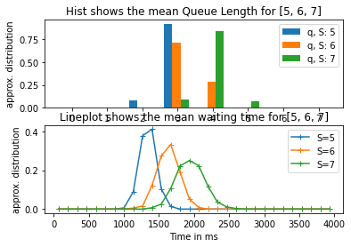

```python
task_2_7_2()
```

# Analysis and General Questions

## 2.8.1 System with different Queue capacity

So, to understand it more cleary, I have in a previous work poltted myself this in a figure similar to the one below. As you can see, for the longer simulation time the starting up phase has much less of an influence since the total number of packages is higher, from a ~400 to ~4000. So, the mean slightly rises. (Be carefull, when I plot the line I force same length for all simulations, so what you see is the least amount of packets in a run! i.e. it should be a bit less than expected but it still serves well for my argument)

```
-----------------------------------------------
Gonna do a sim with paras - S:5
```

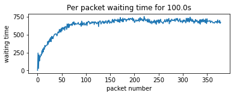

```
Gonna do a sim with paras - S:5
```

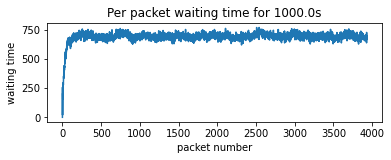

```python
pp.subplot(2,1,1)
task_2_7_1(True, S_VALUES=[5])
pp.subplot(2,1,2)
task_2_7_2(True, S_VALUES=[5])
```

## 2.8.2 Choosing the right number of bins

For the mean queue length histogram it is quite obvious to use S+1 bins, since 0 is possible. For me, it was much more difficult to write the code for the plot but ok.

For the lineplot I had to consider a bit more. First, I ran a few simulations to get a feeling for the maximum waiting time. I found that values above 3000ms are very rare and I decided to be save and set it to 4k ms. The number of bins is more important. At first, I have 20 bins, so one for every 200 ms, it turns out this is not enough, especially the plot with longer runtime becomes much to peaky at a single value. SO I doubled it to 40, I realized there are now to many spikes, like a really pointy mountain has. So, I lowered it to 30. THis looks good now.

Funily enough, I didnt really the rule of thumb to be much of use, I always have to consider the actual data I want to represent

## 2.8.3 Variance Calculation

1. We always operate on a sample of all possible outcomes of our experiment that we want to know the variance of. So, directly calculating the mean μ and variance 𝜎^2 (formula with 1/n) means that they are random variables two, since it is possible to choose different samples to calculate the variance and mean from.
2. If we now do a funny thing and calculate the mean of the variance 𝜎^2 we find that it is biased as E[𝜎^2] = (n-1)/n*𝜎^2
3. If we want to get rid of that n-1 we simply divide by it and voilà there is the unbiased emperical variance formula

Source: All the math has been done by wiser people before and this explanation is heavily influenced by [Sample mean wiki](https://en.wikipedia.org/wiki/Variance#Sample_variance) and lessons from the lecture